# Divvy (Chicago, IL) Bike Share Exploration

## Dataset (2018 - 2019)

## Preliminary Wrangling

**Divvy is a bicycle sharing system in the City of Chicago and two adjacent suburbs operated by Lyft for the Chicago Department of Transportation. As of July 2019, it operated 5800 bicycles at 608 stations, covering almost all of the city. The datasets were obtained from https://www.divvybikes.com/system-data for the years 2018 and 2019, they were unzipped and placed in my local BikeTripData directory.**

```python
# import all packages and set plots to be embedded inline
import numpy as np
import pandas as pd
import matplotlib.pyplot as plt
import seaborn as sns
import glob
import time
import warnings
from statsmodels.graphics.mosaicplot import mosaic
from IPython.display import display

start = time.time()
warnings.filterwarnings('ignore')
%matplotlib inline
```

**Loading the datasets...**

```python
all_files = glob.glob('BikeTripData/Divvy_Trips_*')
col_names=['trip_id', 'start_time', 'end_time', 'bikeid', 'tripduration',
           'from_station_id', 'from_station_name', 'to_station_id',
           'to_station_name', 'usertype', 'gender', 'birthyear']
df = pd.concat((pd.read_csv(file, names=col_names, low_memory=False) for file in all_files))

print('All the following dataset files were read into the dataframe:')
print()
for file in all_files:
    print(file)
```

```
All the following dataset files were read into the dataframe:

BikeTripData\Divvy_Trips_2018_Q1.csv
BikeTripData\Divvy_Trips_2018_Q2.csv
BikeTripData\Divvy_Trips_2018_Q3.csv
BikeTripData\Divvy_Trips_2018_Q4.csv
BikeTripData\Divvy_Trips_2019_Q1
BikeTripData\Divvy_Trips_2019_Q2
BikeTripData\Divvy_Trips_2019_Q3.csv
BikeTripData\Divvy_Trips_2019_Q4.csv
```

```python
def my_describe(df):
    print('='*40)
    print('We have', df.shape[0], 'rows, and', df.shape[1], 'columns.')
    print('='*40)
    desc = df.describe([], include='all', datetime_is_numeric=True).T.replace(np.nan,'-')
    desc['type'] = df.dtypes.astype('str')
    desc['count'] = desc['count'].astype('int')
    if len(df.select_dtypes('number').columns):
        desc = desc[['type', 'count', 'unique', 'top', 'freq', 'mean', 'std', 'min', '50%', 'max']]
    else:
        desc = desc[['type', 'count', 'unique', 'top', 'freq']]
    return desc.sort_values(['type', 'count'])
```

```python
rows_ini = df.shape[0]
cols_ini = df.shape[1]

display(df.head())
display(my_describe(df))
```

|  | trip_id | start_time | end_time | bikeid | tripduration | from_station_id | from_station_name | to_station_id | to_station_name | usertype | gender | birthyear |
| --- | --- | --- | --- | --- | --- | --- | --- | --- | --- | --- | --- | --- |
| 0 | 01 - Rental Details Rental ID | 01 - Rental Details Local Start Time | 01 - Rental Details Local End Time | 01 - Rental Details Bike ID | 01 - Rental Details Duration In Seconds Uncapped | 03 - Rental Start Station ID | 03 - Rental Start Station Name | 02 - Rental End Station ID | 02 - Rental End Station Name | User Type | Member Gender | 05 - Member Details Member Birthday Year |
| 1 | 17536702 | 2018-01-01 00:12:00 | 2018-01-01 00:17:23 | 3304 | 323.0 | 69 | Damen Ave & Pierce Ave | 159 | Claremont Ave & Hirsch St | Subscriber | Male | 1988 |
| 2 | 17536703 | 2018-01-01 00:41:35 | 2018-01-01 00:47:52 | 5367 | 377.0 | 253 | Winthrop Ave & Lawrence Ave | 325 | Clark St & Winnemac Ave (Temp) | Subscriber | Male | 1984 |
| 3 | 17536704 | 2018-01-01 00:44:46 | 2018-01-01 01:33:10 | 4599 | 2,904.0 | 98 | LaSalle St & Washington St | 509 | Troy St & North Ave | Subscriber | Male | 1989 |
| 4 | 17536705 | 2018-01-01 00:53:10 | 2018-01-01 01:05:37 | 2302 | 747.0 | 125 | Rush St & Hubbard St | 364 | Larrabee St & Oak St | Subscriber | Male | 1983 |

```
========================================
We have 7421094 rows, and 12 columns.
========================================
```

|  | type | count | unique | top | freq |
| --- | --- | --- | --- | --- | --- |
| gender | object | 6299383 | 4 | Male | 4682661 |
| birthyear | object | 6327134 | 102 | 1992 | 376099 |
| trip_id | object | 7421094 | 7421088 | trip_id | 6 |
| start_time | object | 7421094 | 6454881 | 2018-07-10 17:33:47 | 10 |
| end_time | object | 7421094 | 6287328 | 2019-04-17 17:35:12 | 20 |
| bikeid | object | 7421094 | 6301 | 6255 | 2493 |
| tripduration | object | 7421094 | 28045 | 320.0 | 7939 |
| from_station_id | object | 7421094 | 634 | 35 | 134927 |
| from_station_name | object | 7421094 | 666 | Streeter Dr & Grand Ave | 134927 |
| to_station_id | object | 7421094 | 634 | 35 | 159944 |
| to_station_name | object | 7421094 | 666 | Streeter Dr & Grand Ave | 159944 |
| usertype | object | 7421094 | 4 | Subscriber | 5863293 |

**The dataframe includes the headers from the CSV files, which made all columns data types object. Let's remove those header rows and then drop all rows with NaNs (specifically in gender and birthyear)...**

```python
### drop headers ###
df = df[~df['bikeid'].str.match('01 - Rental Details Bike ID')]
df = df[~df['bikeid'].str.match('bikeid')]

### drop nulls ###
df = df.dropna()

### report ###
print('We dropped', '{:,}'.format(rows_ini-df.shape[0]),
      '({:.3%})'.format(round((1-df.shape[0]/rows_ini),6)),
      'out of', '{:,}'.format(rows_ini),
      'rows. Ending up with', '{:,}'.format(df.shape[0]), 'rows.')
print()
print('We also have', df.isnull().sum().sum(), 'null values.')
```

```
We dropped 1,121,781 (15.116%) out of 7,421,094 rows. Ending up with 6,299,313 rows.

We also have 0 null values.
```

**Now I will modify some data types and add some columns that will aid my analysis...**

```python
### change data types ###
df['start_time'] = df['start_time'].astype('datetime64')
df['birthyear'] = df['birthyear'].astype('int16')
df['tripduration'] = df['tripduration'].str.replace(',', '').astype('float64')/60 # in minutes

### add time related columns ###
df['year'] = df['start_time'].dt.year
df['month'] = df['start_time'].dt.month
df['month_name'] = df['start_time'].dt.month
df['day_num'] = df['start_time'].dt.dayofweek
df['day_of_week'] = df['start_time'].dt.dayofweek
df['hour'] = df['start_time'].dt.hour

### drop end time ###
del df['end_time']

### fix days of week ###
days = {0:'Mon', 1:'Tue', 2:'Wed', 3:'Thu', 4:'Fri', 5:'Sat', 6:'Sun'}
df['day_of_week'] = df['day_of_week'].apply(lambda x: days[x])
weekdays = ['Mon', 'Tue', 'Wed', 'Thu', 'Fri', 'Sat', 'Sun']
df['day_of_week'] = pd.Categorical(df['day_of_week'], categories=weekdays, ordered=True)

### fix month names ###
months = {1:'Jan', 2:'Feb', 3:'Mar', 4:'Apr', 5:'May', 6:'Jun', 7:'Jul',
          8:'Aug', 9:'Sep', 10:'Oct', 11:'Nov', 12:'Dec'}
df['month_name'] = df['month_name'].apply(lambda x: months[x])
month_ord = ['Jan', 'Feb', 'Mar', 'Apr', 'May', 'Jun',
             'Jul', 'Aug', 'Sep', 'Oct', 'Nov', 'Dec']
df['month_name'] = pd.Categorical(df['month_name'], categories=month_ord, ordered=True)

### add season ###
season = ['Winter','Spring','Summer','Fall']
seasons = dict(zip(range(1,13),
                   [season[(mon%12+3)//3-1] for mon in range(1,13)]))
df['season'] = df['month'].apply(lambda x: seasons[x]).astype('category')

### add age and age groups ###
df['age'] = 2019 - df['birthyear']
df = df[df['age'] >= 14]
df = df[df['age'] <= 80]
df['age_group'] = pd.cut(x=df['age'], bins=[0, 29, 39, 49, 59, np.inf],
                         labels=['<29', '30s', '40s', '50s', '60+'])
```

**Now I will add some station location data to enrich my analysis...**

```python
# df_sta = pd.read_json('https://gbfs.divvybikes.com/gbfs/en/station_information.json')
# df_sta = pd.DataFrame(df_sta.data.to_list()[0])
# df_sta = df_sta[['station_id','lat', 'lon']]

# df_sta.set_index('station_id', inplace=True)

# from geopy.geocoders import Nominatim
# from geopy.extra.rate_limiter import RateLimiter

# geolocator = Nominatim(user_agent="Divvy_Bikeshare_Project_Udacity")
# reverse = RateLimiter(geolocator.reverse, min_delay_seconds=1, max_retries=0)

# locs = []
# for index, row in df_sta.iterrows():
#     locs.append(reverse('{}, {}'.format(row['lat'], row['lon'])).raw['address'])

# df_stations = pd.DataFrame(index=df_sta.index, data=locs, columns=['neighbourhood','suburb'])
# df_stations[['lat','lon']] = df_sta[['lat','lon']]

# df_stations.to_csv('station_information.csv')
```

**The cell above was executed once... the goal was to retrieve latitude and longitude data from Divvy's server, then using geopy reverse geo location to retrieve suburb data for each bike station... The resulting data frame was saved to CSV to be used in the next cell...**

```python
df_stations = pd.read_csv('station_information.csv')
df_stations['station_id'] = df_stations['station_id'].astype('int').astype('str')

df = df.merge(df_stations[['lat', 'lon', 'suburb', 'station_id']], how='left',
              left_on='from_station_id', right_on='station_id').drop(columns=['station_id'])
df = df.merge(df_stations[['lat', 'lon', 'suburb', 'station_id']], how='left', suffixes=('_from', '_to'),
              left_on='to_station_id', right_on='station_id').drop(columns=['station_id'])
```

```python
# def distance(lat1, lon1, lat2, lon2):
#     dlat = np.radians(lat2-lat1)
#     dlon = np.radians(lon2-lon1)
#     a = np.sin(dlat/2) \
#         * np.sin(dlat/2) \
#         + np.cos(np.radians(lat1)) \
#         * np.cos(np.radians(lat2)) \
#         * np.sin(dlon/2) \
#         * np.sin(dlon/2)
#     return 6371 * 2 * np.arctan2(np.sqrt(a), np.sqrt(1-a))
# df['distance'] = distance(df['lat_from'], df['lon_from'], df['lat_to'], df['lon_to'])

df['str_dist'] = (abs(df['lat_from']-df['lat_to']) * 111
                 +abs(df['lon_from']-df['lon_to']) * 84)

df['speed'] = df['str_dist'] / (df['tripduration'] / 60) # km/h
```

```python
my_describe(df)
```

```
========================================
We have 6296766 rows, and 28 columns.
========================================
```

|  | type | count | unique | top | freq | mean | std | min | 50% | max |
| --- | --- | --- | --- | --- | --- | --- | --- | --- | --- | --- |
| month_name | category | 6296766 | 12 | Aug | 910757 | - | - | - | - | - |
| day_of_week | category | 6296766 | 7 | Wed | 1043867 | - | - | - | - | - |
| season | category | 6296766 | 4 | Summer | 2538737 | - | - | - | - | - |
| age_group | category | 6296766 | 5 | 30s | 2326488 | - | - | - | - | - |
| start_time | datetime64[ns] | 6296766 | - | - | - | 2019-01-23 10:48:17.828851712 | - | 2018-01-01 00:12:00 | 2019-02-04 17:47:37 | 2019-12-31 23:57:17 |
| str_dist | float64 | 6295215 | - | - | - | 2.603806 | 2.169721 | 0.0 | 1.934139 | 41.706549 |
| speed | float64 | 6295215 | - | - | - | 12.421481 | 4.342853 | 0.0 | 12.710314 | 150.093616 |
| lat_to | float64 | 6295720 | - | - | - | 41.90004 | 0.037604 | 41.736646 | 41.892278 | 42.064854 |
| lon_to | float64 | 6295720 | - | - | - | -87.644327 | 0.022264 | -87.774704 | -87.640981 | -87.549386 |
| lat_from | float64 | 6295969 | - | - | - | 41.899401 | 0.037259 | 41.736646 | 41.891847 | 42.064854 |
| lon_from | float64 | 6295969 | - | - | - | -87.643965 | 0.022132 | -87.774704 | -87.639904 | -87.549386 |
| tripduration | float64 | 6296766 | - | - | - | 16.876334 | 348.926106 | 1.016667 | 10.166667 | 225960.0 |
| birthyear | int16 | 6296766 | - | - | - | 1983.440595 | 10.820635 | 1939.0 | 1987.0 | 2005.0 |
| age | int16 | 6296766 | - | - | - | 35.559405 | 10.820635 | 14.0 | 32.0 | 80.0 |
| year | int64 | 6296766 | - | - | - | 2018.51736 | 0.499699 | 2018.0 | 2019.0 | 2019.0 |
| month | int64 | 6296766 | - | - | - | 7.057696 | 2.695522 | 1.0 | 7.0 | 12.0 |
| day_num | int64 | 6296766 | - | - | - | 2.703254 | 1.882792 | 0.0 | 3.0 | 6.0 |
| hour | int64 | 6296766 | - | - | - | 13.614809 | 4.790452 | 0.0 | 15.0 | 23.0 |
| suburb_to | object | 6283949 | 51 | Near North Side | 1281836 | - | - | - | - | - |
| suburb_from | object | 6284420 | 51 | Near North Side | 1299707 | - | - | - | - | - |
| trip_id | object | 6296766 | 6296766 | 25812025 | 1 | - | - | - | - | - |
| bikeid | object | 6296766 | 6297 | 6255 | 2222 | - | - | - | - | - |
| from_station_id | object | 6296766 | 629 | 192 | 112290 | - | - | - | - | - |
| from_station_name | object | 6296766 | 661 | Canal St & Adams St | 112290 | - | - | - | - | - |
| to_station_id | object | 6296766 | 630 | 192 | 105699 | - | - | - | - | - |
| to_station_name | object | 6296766 | 662 | Canal St & Adams St | 105699 | - | - | - | - | - |
| usertype | object | 6296766 | 2 | Subscriber | 5829105 | - | - | - | - | - |
| gender | object | 6296766 | 2 | Male | 4680230 | - | - | - | - | - |

**I noticed that the maximum speed and tripduration are unrealistic, so after some research I decided on the following filters: (a) filter out the trips where the trip duration was more than 5 hours, and (b) filter out the trips where the trip speed was more than 30 km/h. Also, I will drop rows with null values.**

```python
df = df[df.tripduration <= 300]
df = df[df.speed <= 30]
df = df.dropna()
```

```python
my_describe(df)
```

```
========================================
We have 6269186 rows, and 28 columns.
========================================
```

|  | type | count | unique | top | freq | mean | std | min | 50% | max |
| --- | --- | --- | --- | --- | --- | --- | --- | --- | --- | --- |
| month_name | category | 6269186 | 12 | Aug | 906967 | - | - | - | - | - |
| day_of_week | category | 6269186 | 7 | Wed | 1039641 | - | - | - | - | - |
| season | category | 6269186 | 4 | Summer | 2528347 | - | - | - | - | - |
| age_group | category | 6269186 | 5 | 30s | 2316864 | - | - | - | - | - |
| start_time | datetime64[ns] | 6269186 | - | - | - | 2019-01-23 10:01:16.380982784 | - | 2018-01-01 00:12:00 | 2019-02-04 17:29:36 | 2019-12-31 23:57:17 |
| tripduration | float64 | 6269186 | - | - | - | 14.039742 | 14.656525 | 1.016667 | 10.166667 | 299.983333 |
| lat_from | float64 | 6269186 | - | - | - | 41.898966 | 0.036417 | 41.736646 | 41.891795 | 42.064854 |
| lon_from | float64 | 6269186 | - | - | - | -87.643824 | 0.022 | -87.774704 | -87.639904 | -87.549386 |
| lat_to | float64 | 6269186 | - | - | - | 41.899609 | 0.036781 | 41.736646 | 41.892278 | 42.064854 |
| lon_to | float64 | 6269186 | - | - | - | -87.644184 | 0.022132 | -87.774704 | -87.640981 | -87.549386 |
| str_dist | float64 | 6269186 | - | - | - | 2.601814 | 2.164231 | 0.0 | 1.934139 | 36.715902 |
| speed | float64 | 6269186 | - | - | - | 12.422818 | 4.302045 | 0.0 | 12.711218 | 29.999554 |
| birthyear | int16 | 6269186 | - | - | - | 1983.456418 | 10.809223 | 1939.0 | 1987.0 | 2005.0 |
| age | int16 | 6269186 | - | - | - | 35.543582 | 10.809223 | 14.0 | 32.0 | 80.0 |
| year | int64 | 6269186 | - | - | - | 2018.517297 | 0.499701 | 2018.0 | 2019.0 | 2019.0 |
| month | int64 | 6269186 | - | - | - | 7.057374 | 2.695097 | 1.0 | 7.0 | 12.0 |
| day_num | int64 | 6269186 | - | - | - | 2.702697 | 1.882524 | 0.0 | 3.0 | 6.0 |
| hour | int64 | 6269186 | - | - | - | 13.614068 | 4.789928 | 0.0 | 15.0 | 23.0 |
| trip_id | object | 6269186 | 6269186 | 25812025 | 1 | - | - | - | - | - |
| bikeid | object | 6269186 | 6295 | 6255 | 2215 | - | - | - | - | - |
| from_station_id | object | 6269186 | 602 | 192 | 112225 | - | - | - | - | - |
| from_station_name | object | 6269186 | 634 | Canal St & Adams St | 112225 | - | - | - | - | - |
| to_station_id | object | 6269186 | 602 | 192 | 105647 | - | - | - | - | - |
| to_station_name | object | 6269186 | 634 | Canal St & Adams St | 105647 | - | - | - | - | - |
| usertype | object | 6269186 | 2 | Subscriber | 5805233 | - | - | - | - | - |
| gender | object | 6269186 | 2 | Male | 4659562 | - | - | - | - | - |
| suburb_from | object | 6269186 | 51 | Near North Side | 1298180 | - | - | - | - | - |
| suburb_to | object | 6269186 | 51 | Near North Side | 1280494 | - | - | - | - | - |

```python
### report ###
print('Overall, we dropped', '{:,}'.format(rows_ini-df.shape[0]),
      '({:.2%})'.format(round((1-df.shape[0]/rows_ini),6)),
      'out of', '{:,}'.format(rows_ini),
      'rows. Ending up with', '{:,}'.format(df.shape[0]), 'rows.')
print()
print('We also have', df.isnull().sum().sum(), 'null values.')
print()

yf = dict(df.year.value_counts(normalize=True, sort=False))
print('Data from 2018 represent {:.2%} of total dataset.'.format(yf[2018]))
print('Data from 2019 represent {:.2%} of total dataset.'.format(yf[2019]))
```

```
Overall, we dropped 1,151,908 (15.52%) out of 7,421,094 rows. Ending up with 6,269,186 rows.

We also have 0 null values.

Data from 2018 represent 48.27% of total dataset.
Data from 2019 represent 51.73% of total dataset.
```

### What is the structure of your dataset?

> **The dataset was originally 7,421,094 rows, and 12 columns. After removing 1,151,908 rows that contain nulls and headers, then removing ages, trip-durations, and speeds that don't seem realistic, it was reduced by 15.52%. However, we still have a dataset with 6,269,186 rows and 28 columns, out of which 48.27% are from 2018 and 51.73% from 2019.**

> **In addition, I have added year, month, month_name, day_num, day_of_week, hour, season, age, and age_group columns to enrich the analysis. Also added some location data to add suburb information and to create str_dist (distance between two stations) and speed.**

### What is/are the main feature(s) of interest in your dataset?

> **I find the tripduration variable the most promising feature to study. But I will also examine distance and speed as main features.**

### What features in the dataset do you think will help support your investigation into your feature(s) of interest?

> **All other original and added features will be used against the interest features to find patterns and/or insights into the data.**

## Univariate Exploration

**We will try first to know our dataset closely by looking at some of the variables...**

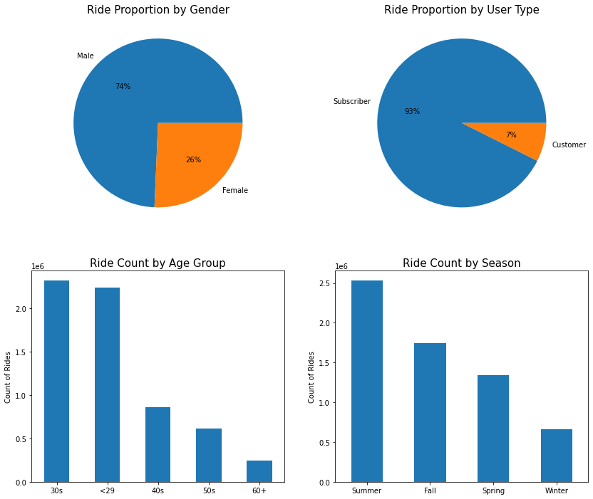

```python
fig, axs = plt.subplots(nrows=2, ncols=2, figsize=[14, 12])

axs[0,0].set_title('Ride Proportion by Gender', fontsize=15)
df['gender'].value_counts().plot(kind='pie', autopct='%1.0f%%', ylabel='', ax=axs[0,0]);

axs[0,1].set_title('Ride Proportion by User Type', fontsize=15)
df['usertype'].value_counts().plot(kind='pie', autopct='%1.0f%%', ylabel='', ax=axs[0,1]);

axs[1,0].set_title('Ride Count by Age Group', fontsize=15)
df['age_group'].value_counts().plot(kind='bar', rot=0, ylabel='Count of Rides', ax=axs[1,0]);

axs[1,1].set_title('Ride Count by Season', fontsize=15)
df['season'].value_counts().plot(kind='bar', rot=0, ylabel='Count of Rides', ax=axs[1,1]);
```

**The dataset tells us that we typically have a male ridership (74%) and subscriber user type (93%). Looking at age groups, naturally younger riders do the most rides, with people in their 30s riding a bit more than those in their 20s or less, the rest of the age groups come next at a decreasing count. Lastly, weather does seem to affect ridership counts, most rides are in warmer weather while least are when it's cold. We will look next at the distribution of the variable tripduration...**

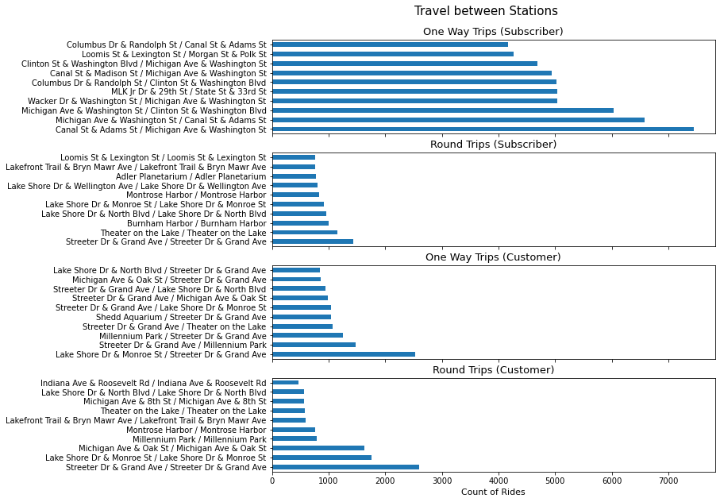

```python
fig, ax = plt.subplots(4, 1, figsize=[10, 10], sharex=True)
df['from_to'] = df['from_station_name'] + ' / ' + df['to_station_name']
# df['to_from'] = df['to_station_name'] + ' / ' + df['from_station_name']
df['from_to'][(df['from_station_name'] != df['to_station_name']) &
              (df['usertype'] == 'Subscriber')].value_counts()[:10].plot(kind='barh', ax=ax[0])
df['from_to'][(df['from_station_name'] == df['to_station_name']) &
              (df['usertype'] == 'Subscriber')].value_counts()[:10].plot(kind='barh', ax=ax[1])
df['from_to'][(df['from_station_name'] != df['to_station_name']) &
              (df['usertype'] == 'Customer')].value_counts()[:10].plot(kind='barh', ax=ax[2])
df['from_to'][(df['from_station_name'] == df['to_station_name']) &
              (df['usertype'] == 'Customer')].value_counts()[:10].plot(kind='barh', ax=ax[3])

fig.suptitle('Travel between Stations', fontsize=15, y=0.94)
ax[0].set_title('One Way Trips (Subscriber)', fontsize=13)
ax[1].set_title('Round Trips (Subscriber)', fontsize=13)
ax[2].set_title('One Way Trips (Customer)', fontsize=13)
ax[3].set_title('Round Trips (Customer)', fontsize=13)
ax[3].set_xlabel('Count of Rides', fontsize=11);
```

**This count bar plot shows the frequency of trips between bike stations. I was interested in the different behaviors of subscribers and customers in terms of one way trips and round trips to the same station. The first graph shows that for subscribers the most popular bike path is from Canal St & Adams St to Michigan Ave & Washington St, while the most popular round trip station is Streeter Dr & Grand Ave. As for customers, the most popular bike path is Lake Shore Dr & Monroe St to Streeter Dr & Grand Ave, while the most popular round trip station is also Streeter Dr & Grand Ave. It is obvious that the one way trips taken by subscribers is much more than any other round or one way trips by almost triple.**

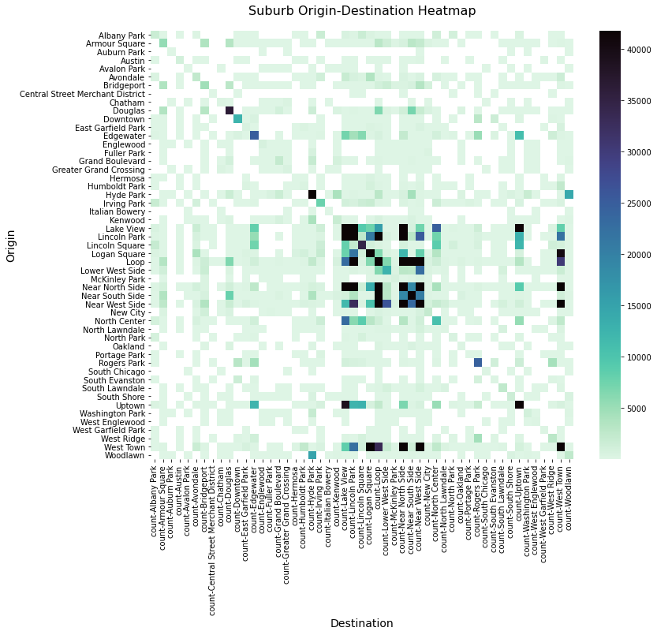

```python
df_temp = df.copy()
df_temp = df_temp.groupby(['suburb_from', 'suburb_to']).size().sort_values()
df_temp = df_temp.reset_index()
df_temp.columns.values[2] = 'count'

min_value = df_temp['count'].quantile(0.02)
max_value = df_temp['count'].quantile(0.98)

df_temp = df_temp.pivot_table(index='suburb_from', columns='suburb_to', fill_value=np.nan)
df_temp.sort_index(level=0, inplace=True)

fig, ax = plt.subplots(figsize=(12,10))
sns.heatmap(df_temp,vmin=min_value,vmax=max_value,cmap='mako_r')

ax.set_title('Suburb Origin-Destination Heatmap', fontdict={'fontsize':16}, pad=20)
ax.set_xlabel('Destination', fontsize=14)
ax.set_ylabel('Origin', fontsize=14);

# adapted from github/Geometrein
```

**This heat-map shows the frequency of suburb origin and destination. On its diagonal, it shows the trips taken within the suburb, and the rest is in between suburbs. The darker the square the more rides as shown on the scale on the right. The blank squares represent NaNs.**

**If we take same suburb activity for example, we can see some suburbs enjoy high rides activity, such as Douglas, Hyde Park, Loop, Near North Side to name a few. As for the in between suburbs rides activity the highest is between Near West Side and Loop in either direction.**

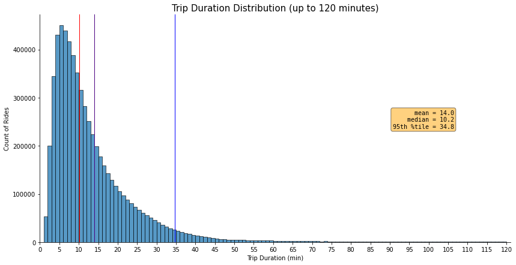

```python
sns.displot(data=df,x='tripduration', bins=np.arange(1,121), height=6, aspect=2)
plt.xlim(0, 121)
x0, xmax = plt.xlim()
y0, ymax = plt.ylim()
data_width = xmax - x0
data_height = ymax - y0
plt.xticks(range(0,121,5))
plt.xlabel('Trip Duration (min)')
plt.ylabel('Count of Rides')
plt.axvline(df['tripduration'].quantile(0.50), lw=1, color='r')
plt.axvline(df['tripduration'].mean(), lw=1, color='indigo')
plt.axvline(df['tripduration'].quantile(0.95), lw=1, color='b')
plt.text(x0+data_width*0.75, y0+data_height*0.5,
         '      mean = '+str(round(df['tripduration'].mean(),1))+'\n'+
         '    median = '+str(round(df['tripduration'].quantile(0.50),1))+'\n'+
         '95th %tile = '+str(round(df['tripduration'].quantile(0.95),1)),
         family='monospace', bbox=dict(boxstyle='round',facecolor='orange',alpha=.5))
plt.title('Trip Duration Distribution (up to 120 minutes)', fontsize=15);
```

**The variable tripduration is a right skewed distribution (mean is 14 minutes). Its median is around 10 minutes, while the 95th percentile is around 35 minutes. Next we will look at the age distribution...**

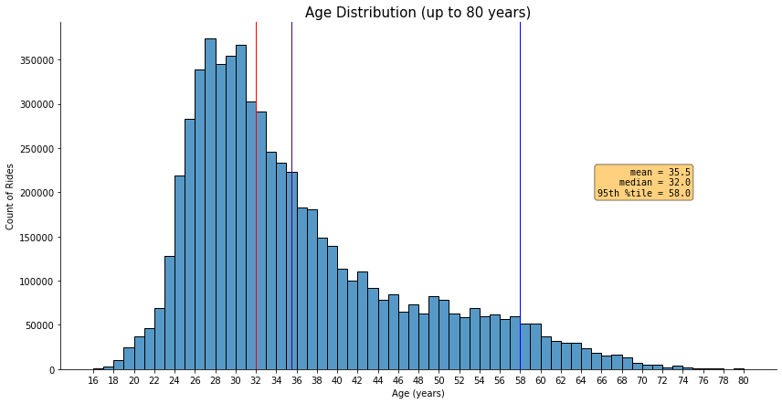

```python
sns.displot(data=df, x='age', bins=np.arange(16,81), height=6, aspect=2)
x0, xmax = plt.xlim()
y0, ymax = plt.ylim()
data_width = xmax - x0
data_height = ymax - y0
plt.xticks(range(16,81,2))
plt.xlabel('Age (years)')
plt.ylabel('Count of Rides')
plt.axvline(df['age'].quantile(0.50), lw=1, color='r')
plt.axvline(df['age'].mean(), lw=1, color='indigo');
plt.axvline(df['age'].quantile(0.95), lw=1, color='b')
plt.text(x0+data_width*0.75, y0+data_height*0.5,
         '      mean = '+str(round(df['age'].mean(),1)) + '\n' +
         '    median = '+str(round(df['age'].quantile(0.50),1)) + '\n' +
         '95th %tile = '+str(round(df['age'].quantile(0.95),1)),
         family='monospace', bbox=dict(boxstyle='round',facecolor='orange',alpha=.5))
plt.title('Age Distribution (up to 80 years)', fontsize=15);
```

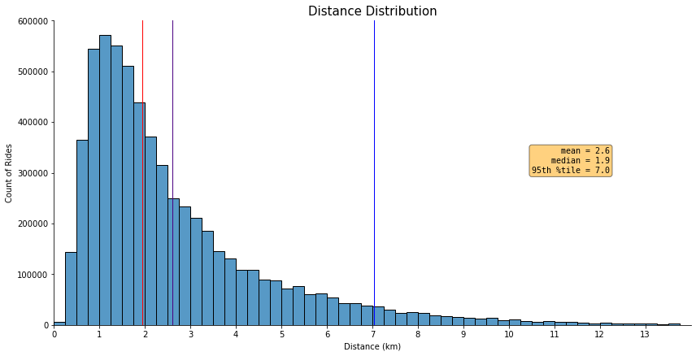

```python
sns.displot(data=df[df['str_dist'] > 0], x='str_dist', bins=np.arange(0,14,.25), height=6, aspect=2)
plt.xlim(0.01, 14)
x0, xmax = plt.xlim()
y0, ymax = plt.ylim()
data_width = xmax - x0
data_height = ymax - y0
plt.xticks(range(0,14))
plt.xlabel('Distance (km)')
plt.ylabel('Count of Rides')
plt.axvline(df['str_dist'].quantile(0.50), lw=1, color='r')
plt.axvline(df['str_dist'].mean(), lw=1, color='indigo');
plt.axvline(df['str_dist'].quantile(0.95), lw=1, color='b')
plt.text(x0+data_width*0.75, y0+data_height*0.5,
         '      mean = '+str(round(df['str_dist'].mean(),1)) + '\n' +
         '    median = '+str(round(df['str_dist'].quantile(0.50),1)) + '\n' +
         '95th %tile = '+str(round(df['str_dist'].quantile(0.95),1)),
         family='monospace', bbox=dict(boxstyle='round',facecolor='orange',alpha=.5))
plt.title('Distance Distribution', fontsize=15);
```

**Again the variable str_distance is a right skewed distribution (mean is 2.6 kilometers). Its median is a bit less 2 kilometers, while its 95th percentile is 7 kilometers. Next we will look at the speed distribution...**

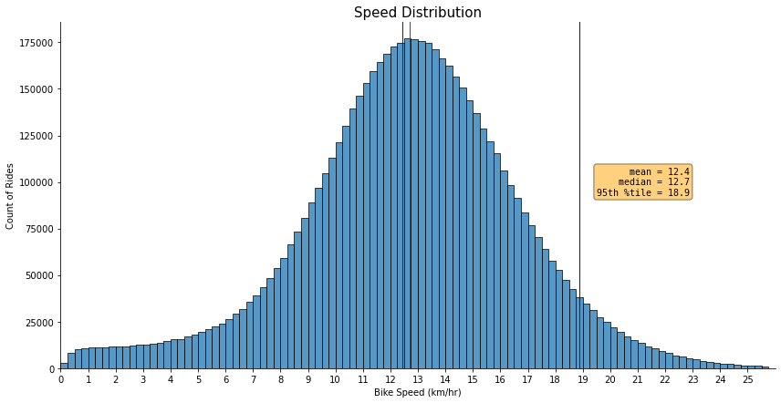

```python
sns.displot(data=df[df['speed'] > 0], x='speed', bins=np.arange(0,26,.25), height=6, aspect=2)
plt.xlim(0.01, 26)
x0, xmax = plt.xlim()
y0, ymax = plt.ylim()
data_width = xmax - x0
data_height = ymax - y0
plt.xticks(range(0,26))
plt.xlabel('Bike Speed (km/hr)')
plt.ylabel('Count of Rides')
plt.axvline(df['speed'].quantile(0.50), lw=1, color='r')
plt.axvline(df['speed'].mean(), lw=1, color='indigo');
plt.axvline(df['speed'].quantile(0.95), lw=1, color='b')
plt.text(x0+data_width*0.75, y0+data_height*0.5,
         '      mean = '+str(round(df['speed'].mean(),1)) + '\n' +
         '    median = '+str(round(df['speed'].quantile(0.50),1)) + '\n' +
         '95th %tile = '+str(round(df['speed'].quantile(0.95),1)),
         family='monospace', bbox=dict(boxstyle='round',facecolor='orange',alpha=.5))
plt.title('Speed Distribution', fontsize=15);
```

**This time we see an almost perfect normal distribution (mean is 12.4 km/hr, with the left tail inflated probably because of inner city traffic). The mean an median are near each other at little less than 13 km/hr, while the 95th percentile is little less than 19 km/hr. Next we will look at hourly patterns during the week.**

```
393.25
```

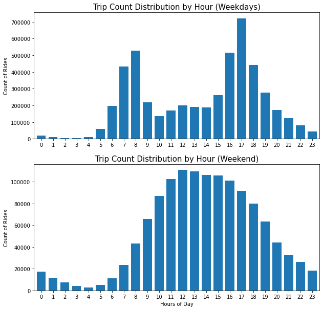

```python
fig, ax = plt.subplots(nrows=2, ncols=1, figsize=[10, 10])
ax[0].set_title('Trip Count Distribution by Hour (Weekdays)', fontsize=15)
ax[0].set_ylabel('Count of Rides')
ax[1].set_xlabel('Hours of Day')
ax[1].set_ylabel('Count of Rides')
ax[1].set_title('Trip Count Distribution by Hour (Weekend)', fontsize=15)
df[df.day_num <  5]['hour'].sort_values().value_counts(sort=False).plot(kind='bar', ax=ax[0], rot=0, width=0.75)
df[df.day_num >= 5]['hour'].sort_values().value_counts(sort=False).plot(kind='bar', ax=ax[1], rot=0, width=0.75);

print(round(df[df.day_num <  5]['hour'].value_counts().mean() /
            df[df.day_num >= 5]['hour'].value_counts().mean() * 100,2))
```

**And just out of personal interest I will look next at a continuous time-line of ride counts to see if we can observe unusual weather effects.**

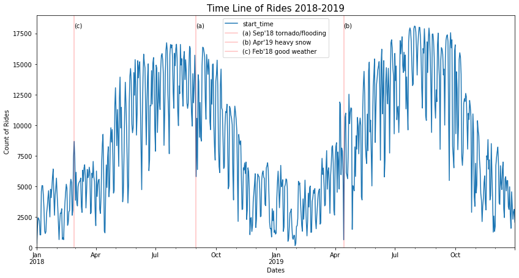

```python
df.groupby(df['start_time'].dt.to_period('D'))['start_time'].count().plot(figsize=(14,7), rot=0)
ax = plt.gca()
ax.set_xlim([df.start_time.min(), df.start_time.max()])
ax.set_ylim(0)
ax.axvline('2018-09-01',alpha=.25,c='r',label='(a) Sep\'18 tornado/flooding')
ax.annotate('(a)', xy=('2018-09-01', 18000))
ax.axvline('2019-04-14',alpha=.25,c='r',label='(b) Apr\'19 heavy snow')
ax.annotate('(b)', xy=('2019-04-14', 18000))
ax.axvline('2018-02-27',alpha=.25,c='r',label='(c) Feb\'18 good weather')
ax.annotate('(c)', xy=('2018-02-27', 18000))
ax.legend()
ax.set_ylabel('Count of Rides')
ax.set_xlabel('Dates')
ax.set_title('Time Line of Rides 2018-2019', fontsize=15);
```

**Indeed, we can see significant drops in bike usage during unusual weather. Just to mention a few examples: (a) tornado and flooding early September 2018, and (b) unusual heavy snow mid April 2019. On the other hand, (c) late February 2018 brought a day of unusual relative warmth and sun following record snow, so ridership naturally increased. But overall, the graph demonstrates the expected rides count increase in warmer weather and decline in colder weather.**

### Discuss the distribution(s) of your variable(s) of interest. Were there any unusual points? Did you need to perform any transformations?

**Except for the speed variable, all distributions were right skewed, which means they tend to have more frequency towards the lower band, for example shorter trips, lower ages, and less distances. There was one unusual point, the male to female ratio which was almost 3 to 1... As for transformation, I only did one, Trip Duration was in seconds and I transformed it into minutes.**

### Of the features you investigated, were there any unusual distributions? Did you perform any operations on the data to tidy, adjust, or change the form of the data? If so, why did you do this?

**As I mentioned above most distributions were right skewed. For the tidiness question, I dropped a little more than 15% of rows mainly because of null values and unusual values.**

## Bivariate Exploration

> In this section, investigate relationships between pairs of variables in your data. Make sure the variables that you cover here have been introduced in some fashion in the previous section (univariate exploration).

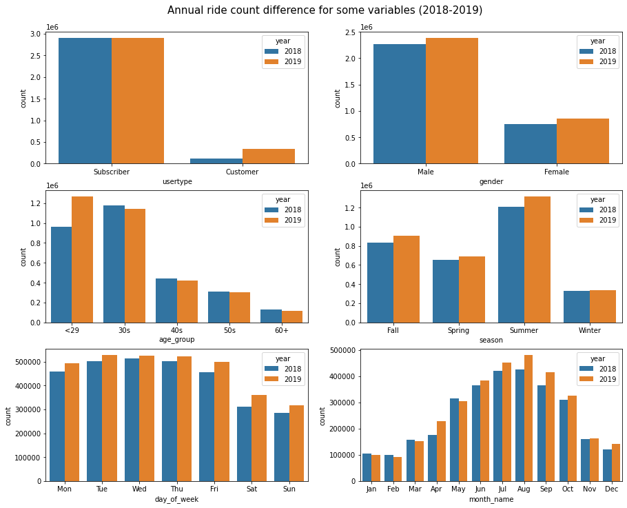

```python
plt.figure(figsize=[15, 12])
plt.subplot(321); sns.countplot(data=df, x='usertype', hue='year')
plt.subplot(322); sns.countplot(data=df, x='gender', hue='year')
plt.subplot(323); sns.countplot(data=df, x='age_group', hue='year')
plt.subplot(324); sns.countplot(data=df, x='season', hue='year')
plt.subplot(325); sns.countplot(data=df, x='day_of_week', hue='year')
plt.subplot(326); sns.countplot(data=df, x='month_name', hue='year')
plt.suptitle('Annual ride count difference for some variables (2018-2019)', y=0.925, fontsize=15);
```

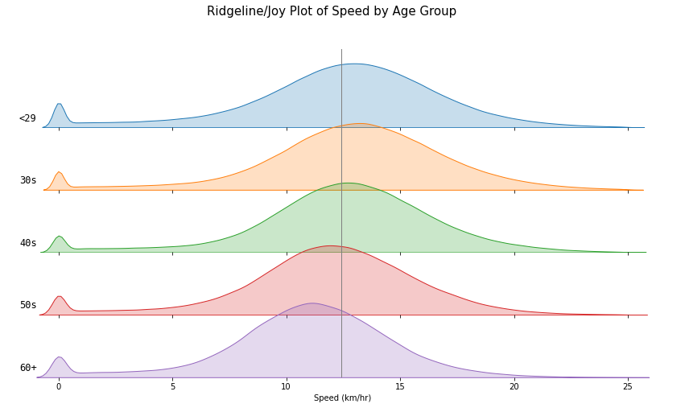

```python
df_temp = df[(df.speed <= 25)] # .sample(1_000_000)

def label(x, color, label):
    ax = plt.gca()
    plt.axvline(df['speed'].mean(), lw=1, c='grey')
    ax.text(0.02, 0.08, label, size='large', family='monospace',
            transform=ax.transAxes)

joy_plot = sns.FacetGrid(df_temp, row='age_group', hue='age_group',
                         size=1.5, aspect=10, gridspec_kws={'hspace':-0.2})
joy_plot.map(sns.kdeplot, 'speed', shade=True)
joy_plot.map(lambda **kwargs: plt.gca().patch.set_alpha(0))
joy_plot.map(label, 'speed')
joy_plot.despine(bottom=True, left=True)
joy_plot.set_titles('')
joy_plot.set(yticks=[])
joy_plot.fig.suptitle('Ridgeline/Joy Plot of Speed by Age Group', fontsize=15)
joy_plot.set_xlabels('Speed (km/hr)');
```

**The Ridgeline plot (sometimes called Joyplot) above shows the distribution of speed for age groups. The distribution are represented using density plots, all aligned to the same horizontal scale and presented with a slight overlap. Two conclusions can be deduced from the plots:**

**(a) the little hump around zero speed: this actually represents zero speeds in the dataset, these are zero because they comprise round trips to the same station, making the distance in turn zero also which results in zero speed. We can see that the density is highest for people in there 20s and below.**

**(b) the main distribution in the middle: I have plotted a line representing the mean across the graphs, it shows that the densities of 20s and below and 30s are highest and above average, while people in their 60s are the slowest with higher density around their mean.**

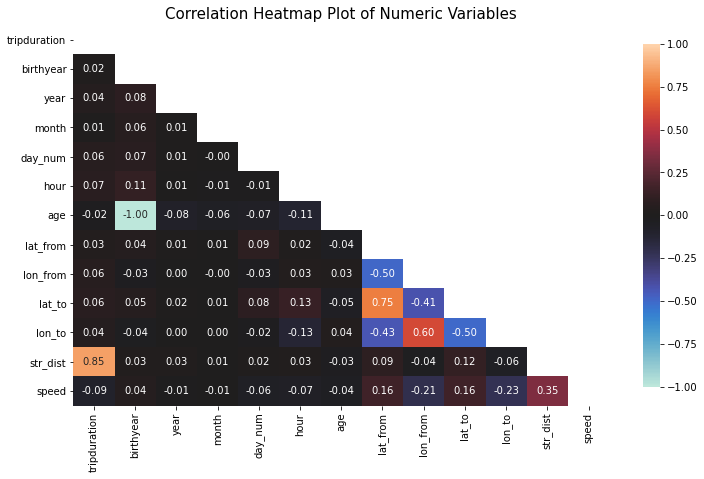

```python
numeric_vars = list(df.select_dtypes(include=[np.number]).columns.values)
df_temp = df[numeric_vars][(df['tripduration'] <= 120) & (df['str_dist'] > 0)]
# df_temp = df_temp[['tripduration', 'birthyear', 'age', 'str_dist', 'speed']]
mask = np.triu(df_temp.corr())

plt.figure(figsize = [12, 7])
plt.title('Correlation Heatmap Plot of Numeric Variables', fontsize=15)
sns.heatmap(df_temp.corr(method='spearman'), mask=mask, annot=True, fmt='.2f', center=0,
           vmin=-1, vmax=1, cbar_kws={'shrink': .9});
```

**The Correlation Heatmap shown above is fairly straight forward, it reveals relationships between the numeric variables in our dataset with assigned colors, the hotter the colors show positive relation, while colder colors show negative relation. We can ignore the relationships of latitudes and longitudes as they signify only that we are in the same area (Chicago), and we can ignore the speed and str_dist correlation because one is calculated from the other. However, the str_dist and tripduration correlation is a positive and strong (0.85) and the two variables are independent of each other. I plan to investigate this further in the next cell...**

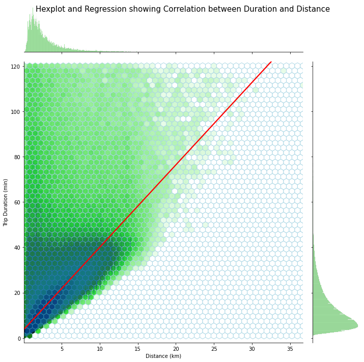

```python
df_temp = df[(df['tripduration'] <= 120) & (df['str_dist'] > 0)] # .sample(1_000_000)
df_temp.rename(columns={'str_dist':'Distance (km)','tripduration':'Trip Duration (min)'}, inplace=True)

x = df_temp['Distance (km)']
y = df_temp['Trip Duration (min)']

g = sns.jointplot(x=x, y=y, data=df_temp, height=10, kind='hex', color='lightgreen',
                  joint_kws={'gridsize':50,'bins':'log','color':'lightblue'})

g.fig.suptitle('Hexplot and Regression showing Correlation between Duration and Distance', fontsize=15)

g = sns.regplot(x=x, y=y, ax=g.ax_joint, line_kws={'color':'r'}, scatter_kws={'s':0.5, 'alpha':0.02})

g.set(ylim=(-2, 122));
```

**Following up from the last graph... Hexplot is one way of exploring and visualizing a bivariate correlation, especially when handling a large datasets, because it splits the plotting window into several hexbins and then the number of observations which fall into each bin corresponds with a color to indicate density, darker color hexbin means that there are more observations or density, within that region. The observation frequency bar graphs can be seen along the spines as an additional reference for information. I used the hexplot to analyze how Trip Duration is related to Distance. We see the darkest hexbins in the bottom left, as it is the most dense because the majority of riders take trips less than 30 minutes and go less than 7 kilometers. As we increase hexbins the color slowly begins to fade. The regression line also confirms the relationship which indicates that there is an increasing positive relationship between the two variables. Lastly, I also plotted the scatter plot of the two variable with low alpha and small size to see if they would pile up and intensify the color and density, which they did in blue.**

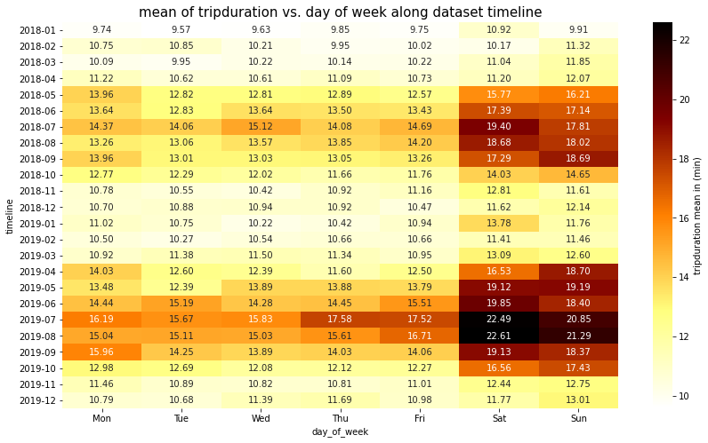

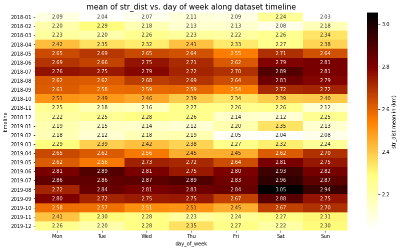

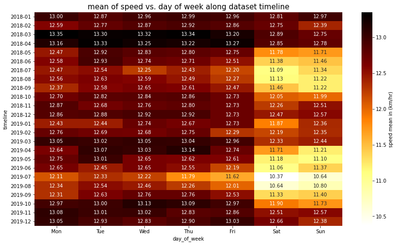

```python
val = ['tripduration', 'str_dist', 'speed']
ats = ['(min)', '(km)', '(km/hr)']

for i in range(3):
    heat = pd.pivot_table(df, values=val[i],
                          index=df['start_time'].dt.to_period('M'),
                          columns=df['day_of_week'],
                          aggfunc='mean')
    fig, ax = plt.subplots(figsize=(14,8))
    sns.heatmap(heat, cmap='afmhot_r', fmt='.2f',
                annot=True, annot_kws={'size':10}, ax=ax,
                cbar_kws={'label':val[i]+' mean in '+ats[i]});
    ax.set_title('mean of '+val[i]+' vs. day of week along dataset timeline', fontsize=15)
    ax.set_ylabel('timeline')
```

**Last but not least we look at our three main features averages across the days of the week along the whole dataset monthly time-line. Starting with Trip Duration, we find that longer ride times took place on the weekends, specifically Saturdays of July and August of 2019, the lowest durations were on January of 2018, Tuesdays being especially the least time. Turning next to Distance, we find people went farther during the warmer months, especially on weekends, the greatest distances were on Saturdays of August 2019, the least distances were also on January of 2018. Finally, we look at Speed, we can certainly see lesser speeds on weekends, March 2018 was the fastest, while July 2019 was slowest.**

### Talk about some of the relationships you observed in this part of the investigation. How did the feature(s) of interest vary with other features in the dataset?

> **There was a strong positive relationships between Distance and Trip Duration (correlation at 0.85) while the two variables were independent of each other.**

### Did you observe any interesting relationships between the other features (not the main feature(s) of interest)?

> **There were two interesting relationships: (a) an increase in rides in 2019 across most non main variables, and (b) a decline of speeds as people age, not an unanticipated finding.**

## Multivariate Exploration

> Create plots of three or more variables to investigate your data even further. Make sure that your investigations are justified, and follow from your work in the previous sections.

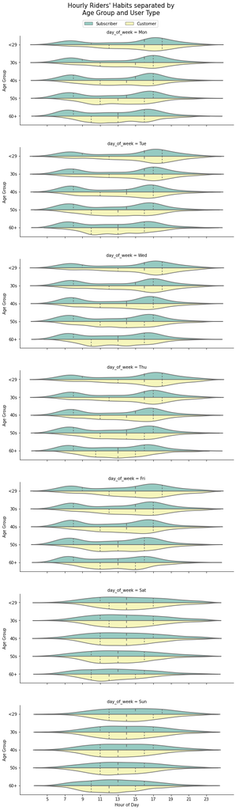

```python
df_temp = df[df['hour']>4] # .sample(1_000_000)

g = sns.catplot(x='hour', y='age_group', hue='usertype', row='day_of_week', data=df_temp,
                height=4, aspect=2, palette='Set3', kind='violin',
                split=True, dodge=True, cut=2, bw=.2, inner='quartile', legend=False)

handles = g._legend_data.values()
labels = g._legend_data.keys()
g.fig.legend(handles=handles, labels=labels, loc=(0.35,0.966), ncol=2)

g.fig.suptitle('Hourly Riders\' Habits separated by\nAge Group and User Type', fontsize=15)
g.fig.subplots_adjust(hspace=0.25, top=0.94)
g.set_axis_labels('Hour of Day', 'Age Group')
g.set(xticks=np.arange(5,24,2))
g.set_xticklabels(np.arange(5,24,2));
```

**There is an upward trend Monday to Friday for all ages at the beginning and the end of the day by subscribers this could be could be because this group is using the bikes for work trips, where as at weekends there was a definite shift of riders during the middle part of the day by both customers and subscribers. Customers were most active during 11am and 3pm, while subscribers are active mostly at 7am and 5pm. The median is almost the same for user types when considering the same age group, with few differences of up to an hour.**

[figure not shown]

```python
# let's take a break
sns.dogplot()
```

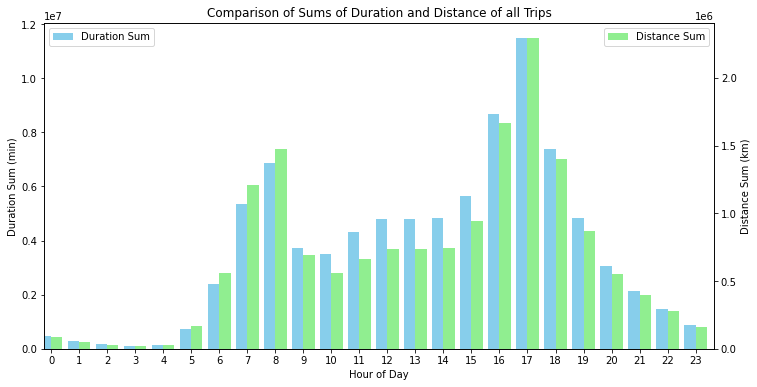

```python
df_temp = df.groupby(['hour']).agg('sum')

fig = plt.figure(figsize=(12,6))

width = 0.4

ax1 = fig.add_subplot(111)
ax1.set_ylabel('Duration Sum (min)')
df_temp.tripduration.plot(kind='bar', color='skyblue', rot=0, ax=ax1, width=width, position=1, label='Duration Sum')

ax2 = ax1.twinx()
ax2.set_ylabel('Distance Sum (km)')
df_temp.str_dist.plot(kind='bar', color='lightgreen', rot=0, ax=ax2, width=width, position=0, label='Distance Sum')

plt.title('Comparison of Sums of Duration and Distance of all Trips')
ax1.set_xlabel('Hour of Day')
ax1.legend(loc='upper left')
ax2.legend(loc='upper right');
```

**We have been looking at counts and means, I want to investigate now the sum of all the data in the dataset. The plot above combines both the Trip Durations Sum and Distances Sum spread out across the Hours of day. I am not surprised that both variables follow the same pattern we've seen before, that is the peak times are still work commute times. I am astonished though by the numbers; taking the hour starting at 5 pm during the two years of the dataset for example, we have a sum of 11.5 million minutes of Trip Duration, and 2.3 million kilometers traveled.**

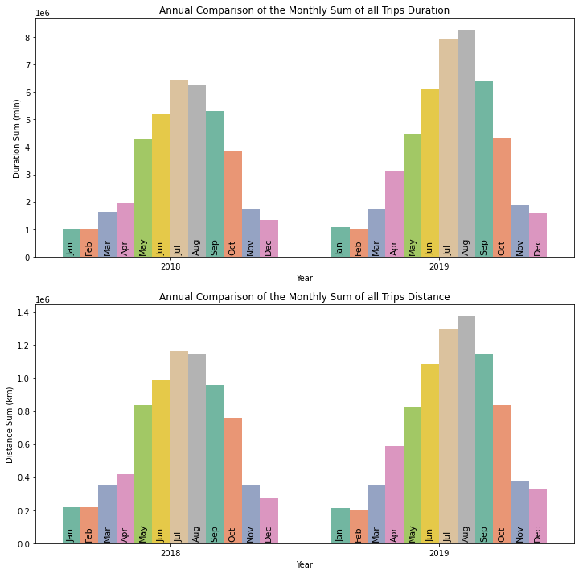

```python
df_temp = df.groupby(['month_name', 'year']).agg('sum')
df_temp.reset_index(level=['month_name','year'], inplace=True)
plt.figure(figsize=(12,12))

plt.subplot(211)
ax=sns.barplot(data=df_temp, x='year', y='tripduration', hue='month_name', palette='Set2')
ax.set_xlabel('Year')
ax.set_ylabel('Duration Sum (min)')
ax.legend_.remove()
y=0
for p in ax.patches:
    ax.annotate(df_temp.month_name[y], (p.get_x()+p.get_width()/2,0),\
    rotation=90, ha='center', size=11, xytext=(0,5), textcoords='offset points')
    y+=1
plt.title('Annual Comparison of the Monthly Sum of all Trips Duration');

plt.subplot(212)
ax=sns.barplot(data=df_temp, x='year', y='str_dist', hue='month_name', palette='Set2')
ax.set_xlabel('Year')
ax.set_ylabel('Distance Sum (km)')
ax.legend_.remove()
y=0
for p in ax.patches:
    ax.annotate(df_temp.month_name[y], (p.get_x()+p.get_width()/2,0),\
    rotation=90, ha='center', size=11, xytext=(0,5), textcoords='offset points')
    y+=1
plt.title('Annual Comparison of the Monthly Sum of all Trips Distance');
```

**We saw this before, the graph shows that warmer weather is contributing to the increase of rides between May and October, in addition to the increase in ridership in 2019. However, we are not counting rides this time, but summing all the minutes traveled (top plot) and kilometers crossed (bottom plot). Taking February for example; around one million minutes spent on bikes in both 2018 and 2019, and around 200,000 kilometers traveled on the same bikes in the same periods. Amazingly, that was the lowest performing month!**

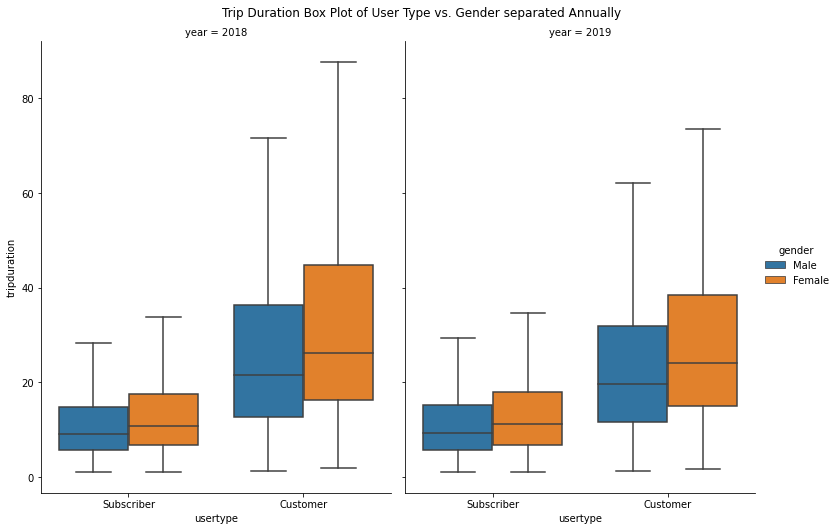

```python
df_temp = df[(df['tripduration'] <= 120) & (df['str_dist'] > 0)] # .sample(3_000_000)

g = sns.catplot(x='usertype', y='tripduration', hue='gender', col='year',
                data=df_temp, kind='box', height=7, aspect=0.75, showfliers=False);
g.fig.suptitle('Trip Duration Box Plot of User Type vs. Gender separated Annually', y=1.02);

# _, ax = plt.subplots(figsize=(13,7))
# mosaic(df_temp, ['gender','usertype','year'], ax=ax, labelizer=lambda _:'',
#        title='Mosaic Plot of User Type vs. Gender separated Annually');
```

**This is a box plot of one numeric variable (Trip Duration) versus three categorical variables (year, usertype, gender). The plot identify details about the cross relations among these variables. For one, females took longer times doing their trips on average, as did customers. However, although we have seen a huge increase in customer rides year-over-year before, we see here that these rides on average were shorter in 2019.**

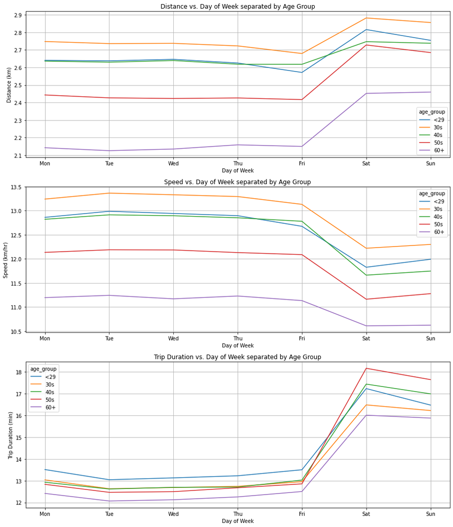

```python
df_temp = df[(df['str_dist'] > 0)] # .sample(3_000_000)

rows, cols = 3, 1
fig, axs = plt.subplots(nrows=rows, ncols=cols, figsize=[15, 18])

titles = ['Distance vs. Day of Week separated by Age Group',
          'Speed vs. Day of Week separated by Age Group',
          'Trip Duration vs. Day of Week separated by Age Group']
ylabels = ['Distance (km)', 'Speed (km/hr)', 'Trip Duration (min)']
ys = ['str_dist', 'speed', 'tripduration']

for i in range(3):
    plt.subplot(rows,cols,i+1)
    plt.grid(b=True)
    plt.xlabel('Day of Week')
    plt.ylabel(ylabels[i])
    plt.title(titles[i])
    sns.lineplot(x='day_of_week', y=ys[i], hue='age_group', data=df_temp, ci=None);
```

**In the first plot, Distance during the weekdays was constant throughout all age groups but shows that the 60+ age group did far less kilometers compared with the other age groups, with the 30s group clocking up the highest distances. The 20s and 40s were almost the same. However, there was a rise in distance traveled for all users on Saturday and Sunday. The second graph shows that all users traveled at a more leisurely pace during the weekend, with the 30s group being the fastest, while 60+ the slowest. The last plot shows that the Trip Duration for all age groups were almost the same (maximum difference of one minute on average) but the over 50s traveled for longer times and the over 60s doing the least on the weekends.**

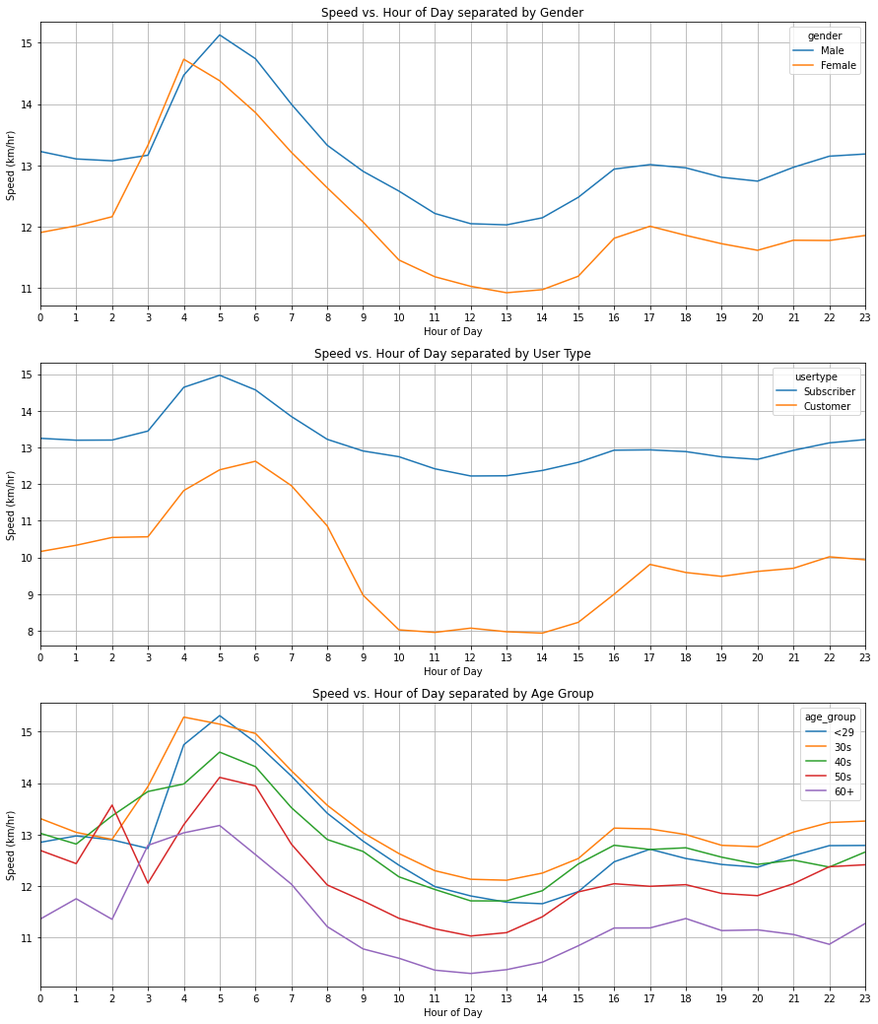

```python
df_temp = df[(df['speed'] > 0)] # .sample(3_000_000)

rows, cols = 3, 1
fig, axs = plt.subplots(nrows=rows, ncols=cols, figsize=[15, 18])

xlimit = [df.hour.min(), df.hour.max()]
titles = ['Speed vs. Hour of Day separated by Gender',
          'Speed vs. Hour of Day separated by User Type',
          'Speed vs. Hour of Day separated by Age Group']
hues = ['gender', 'usertype', 'age_group']

for i in range(3):
    plt.subplot(rows,cols,i+1)
    plt.xticks(range(0,24))
    plt.xlim(xlimit)
    plt.grid(b=True)
    plt.xlabel('Hour of Day')
    plt.ylabel('Speed (km/hr)')
    plt.title(titles[i])
    sns.lineplot(x='hour', y='speed', hue=hues[i], data=df_temp, ci=None);
```

**This line plot is for one numeric variable (Speed) versus one categorical (Hour of Day) separated by three different categorical variables (gender, usertype, age group). The plot identify details about the cross relations among these variables. In the first plot we can see that both males and females were fastest during the earliest hours of the day, this is when possibly when using the bikes for exercise or because of low traffic, this is followed by both genders using the bikes for more regular speeds later in the day, followed by another peak at commute and again later in the evening. The difference is one km/hr for the most part, males being faster.**

**In the second plot, subscribers and customers are making the fastest trips during the earliest hours of the day, probably for the same reasons as mentioned. It is almost exactly the same pattern throughout the day, but with marked differences in speed of 2 to 4 km/hr, subscribers being the fastest.**

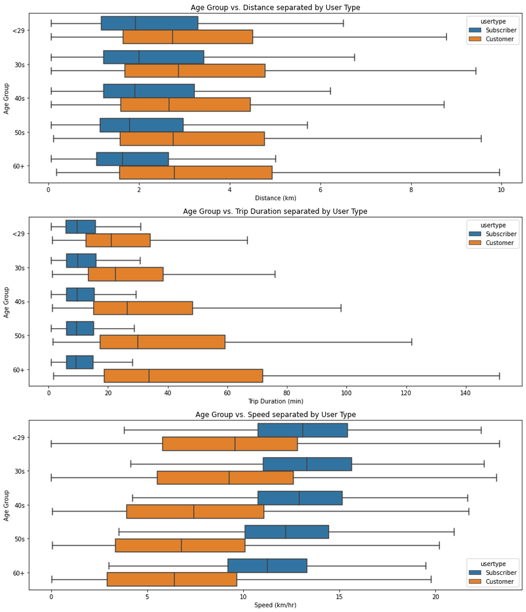

```python
df_temp = df[(df['str_dist'] > 0)] # .sample(3_000_000)

rows, cols = 3, 1
fig, axs = plt.subplots(nrows=rows, ncols=cols, figsize=[15, 18])

titles = ['Age Group vs. Distance separated by User Type',
          'Age Group vs. Trip Duration separated by User Type',
          'Age Group vs. Speed separated by User Type']
xlbls = ['Distance (km)', 'Trip Duration (min)', 'Speed (km/hr)']
xs = ['str_dist', 'tripduration', 'speed']

for i in range(3):
    plt.subplot(rows,cols,i+1)
    sns.boxplot(data=df_temp,x=xs[i],y='age_group',hue='usertype',
                showfliers=False,orient='h');
    plt.title(titles[i])
    plt.xlabel(xlbls[i])
    plt.ylabel('Age Group')
```

**In the first plot we can see that subscribers do shorter distances in all age ranges. In contrast the customers in the 60s category do twice as much distance than the subscribers.**

**In the second plot, Trip Duration is much higher in all age groups by customers, this could be that customers have more leisure time and want to make the most of the bike for the duration, with the over 60s having the most time.**

**The last plot shows that customers of all ages are using the bikes for less speedy journeys compared with subscribers who are using the bikes for more purposeful and brief journeys.**

### Talk about some of the relationships you observed in this part of the investigation. Were there features that strengthened each other in terms of looking at your feature(s) of interest?

> **I discovered that the main features: Trip Durations, Distances, and Speeds, bring out several observations, I will mention the most major in my opinion: (a) Distance and Duration behave similarly although unrelated variables whether when we count or sum their values. (b) The difference of riders behavior during weekdays and weekends when considering many variations of graphs. (c) The odd pattern of higher speeds at the early morning hours no matter the separating variables. (d) The distinct difference in behavior among User Types.**

### Were there any interesting or surprising interactions between features?

> **I guess the most surprising is the odd pattern of higher speeds at the early morning hours no matter the separating variables observed when splitting the data by Gender, User Type, or Age Group.**

#### References:

1. Udacity lessons and exercises
2. MISK/Udacity weekly sessions by Manar Jawarneh (Session Lead)
3. Python documentation from python.org
4. NumPy documentation from numpy.org
5. Pandas documentation from pandas.pydata.org
6. Matplotlib documentation from matplotlib.org
7. Seaborn documentation from seaborn.pydata.org
8. stackoverflow.com
9. kaggle.com
10. medium.com and towardsdatascience.com
11. GeeksforGeeks.org

```python
end = time.time()
hours, rem = divmod(end-start, 3600)
minutes, seconds = divmod(rem, 60)
print("{:0>2}:{:0>2}:{:04.1f}".format(int(hours),int(minutes),seconds))
```

```
00:14:25.4
```

```python
# !jupyter nbconvert --to slides --TemplateExporter.exclude_input=True ##FILE_NAME.ipynb
```